# Lab 1

September 2, 2014

## Introduction

Welcome to the Research and Data Analysis Lab! You will be spending your time in here practicing research design, statistical methods, and computing in the environment, R.

- Homeworks are given in lab, and are optional (they can replace a test grade)
- Lab participation is not optional, and is 15% of your grade
- Your final project will most likelye REQUIRE you to use R

## What the heck is R?

- R is a programming environment based on the language S+ that is used for statistical computing
- It works by creating an execution environment that is the same across all kinds of devices (Windows 8, Mac OSX, Ubuntu, RHEL, OpenSUSE)
- It is written by statisticians, so it is very powerful but a little funky

## Getting set up

- Login to your computers with:
- ID: !tmfpsych101
- Password: c@1thinking

## Starting R

- Click on the R icon, and you should see a window containing a command prompt
- In this prompt, you are going to type `library(Rcmdr)`
- If you see an error that says `there is no package called 'Rcmdr'`, you will first have to type in `install.packages('Rcmdr')`

## It's a little funky

- If you haven't used a programming language before, it might seem strange that one of those is in quotes and the other is not
- What is happening here is that the `library()` command loads a function, and expects a variable label that the system already knows about, or an object
- If you haven't got the package already installed, you must use the `install.packages` function to look through a list of names, or strings, for the particular package you want to install
- strings are denoted by quotation marks, but objects do not need them

## Some basic things

- R does all the basic calculator-type functions you would expect out of a programming language
- Try typing in the following commands:

```r
4 + 5
```

```
## [1] 9
```

```r
4 == 5
```

```
## [1] FALSE
```

```r
4 %in% c(4,5,6)
```

```
## [1] TRUE
```

- See that 'c'? You can't pass R a list of numbers the way you can with other programming languages, so you have to combine them into a vector first using the concatenate function.

## Errors

- We'll be working in Rcmdr, so you probably won't need to use any of this unless you get error messages. The most common beginner errors in R are:
1. Not using quotation marks for strings
2. Not using the `c()` function to create vectors
3. Entering objects as the wrong class
- If you get an error you don't understand, ask me or try googling '[r] your error message'

## Rcmdr

- R commander is a graphical user interface (GUI) written to run on top of R
- It makes R a lot easier to use, because most of the time you will not need to know how the language is actually working
- However, it is very limited in the kinds of analyses it can supports

## Math Review

For this course, you are expected to already have a mastery of algebra. We do not anticipate this to be a problem, but just to be safe, we will begin by reviewing the math concepts that you are expected to know.

## Order of operations

1. Evaluate expressions inside parentheses
2. Evaluate powers left to right
3. Evaluate multiplication/division left to right
4. Evaluate addition/subtraction left to right

## Try these by hand

- 4 + 2 * 3
- 32 * 4<sup>2</sup>
- (8 - 4)<sup>2</sup>/4

## Now type them into the console in R

```r
4 + 2 * 3
```

```
## [1] 10
```

```r
32 * 4 ** 2
```

```
## [1] 512
```

```r
((8 - 4) **2)/4
```

```
## [1] 4
```

## Lines in Cartesian coordinates

A line is composed of two parts: a slope and an intercept

1. A slope is a coefficient attached to a variable, like 2X. You can calculate a slope by dividing the change in Y by the change in X.
2. An intercept is a constant value like 4. You can calculate an intercept by finding where a line crosses the Y axis.

## Imagine you have two data points (1,6) and (2,8)

The slope is calculated as `(Y2-Y1)/(X2-X1)`:

```r
m <- (8-6)/(2-1)
print(m)
```

```
## [1] 2
```

and the intercept is calculated as `Y1 - m*X1`:

```r
b <- (6 - 1 * m)
print(b)
```

```
## [1] 4
```

## Which gives you a line that looks like this:

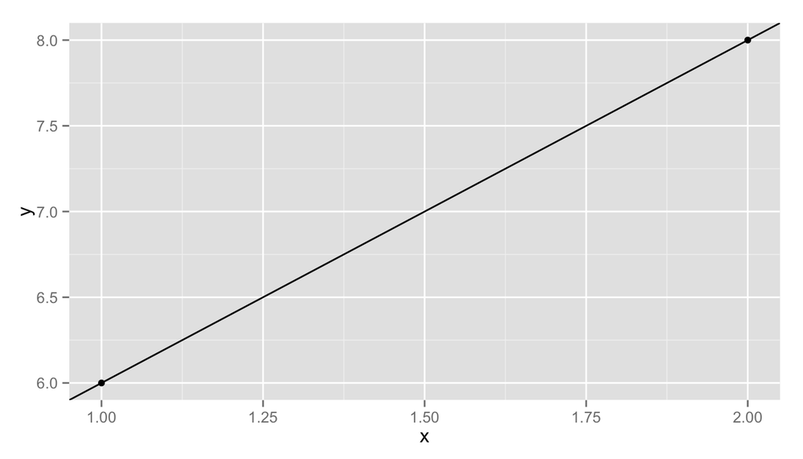

## Now you try

- Calculate the slope and intercept of the line crossing through these two points: (4,6) (6,4)
- Check your answer by calculating this in R

```
data <- data.frame(x = c(4,6), y = c(6,4))
summary(lm(y ~ x, data))
```

## Summation

Summation notation is a shorthand for when you are adding a bunch of similar things together. They are evaluated like this:

[output not shown]

## Try calculating these sums

```
 5
Sigma i^2^
 1


 5
(Sigma i)^2^
 1
```

## Finally

- Any materials that I create for this class will be available at https://github.com/deniederhut/Psych-101-Fall-2014
- These materials will all be written in R, so you can see both the final product and the code that produced it if you like
- If you have questions, you can see me (or Dr. Lee, or one of the other TAs) during office hours
- Let's get started on today's lab activity!